# Part II - Ford GoBike Investigation

## by Abdulmohsen Ali Albareed

## Investigation Overview

### Overall Goals of the Presentation:

1.Provide an overview of the key insights from the analysis of the rider dataset.

2.Highlight the main threads of analysis and their significance.

3.Present visualizations and data summaries to support the findings.

4.Discuss the implications of the insights and their potential applications.

5.Facilitate a clear understanding of the rider characteristics, their impact on trip duration and distance, and the

6.relationship between weekdays and ride patterns.

### Summary of Key Insights:

1.Thursday is the most popular day for riders to make a trip, while Sunday and Saturday have the fewest rides by subscribers.

3.Trip durations range from 1 to 60 minutes, with a right-skewed distribution.

4.Trip distances range from 100 meters to 8 kilometers, also skewed to the right.

5.Birth dates of riders span from the 1940s to the 2000s, with a left-skewed distribution.

6.Riders heading to Parker Ave at McAllister St, Mendell St at Fairfax Ave, or Williams Ave at Apollo St will travel approximately 4 kilometers.

7.Riders starting their ride from Williams Ave at Apollo St will need to travel more than 5 kilometers to reach their destination.

8.Riders born between the 1960s and 1980s perform better in terms of duration and distance compared to those born in the 2000s.

9.Female riders take an average of 12.48 minutes to complete 1.7 kilometers, while male riders take 10.7 minutes to complete 1.6 kilometers.

10.Riders tend to take more time on their trips during Saturdays and Sundays.

## Dataset Overview

The Ford GoBike system dataset provides anonymized, timestamped data about the start- and end- station for a bike, the user type (subscriber or casual rider), as well as some customer-reported attributes like birth year and gender. If you’re already familiar with the CitiBike NYC or RideIndego datasets, the Ford GoBike dataset is similarly structured.

## Number of trips per days

Based on the dataset we have,we found that Thursday has the most trips in a week with more than 30k trips,while Sunday and Saturday have the lowest number of trips in the weekdays with almost 15k trips.

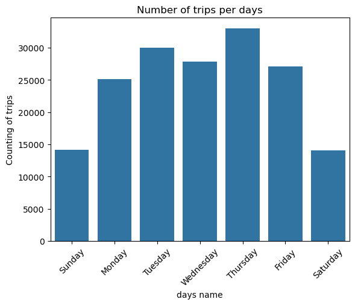

## the difference between Male and Female in the number of trips based on user type.

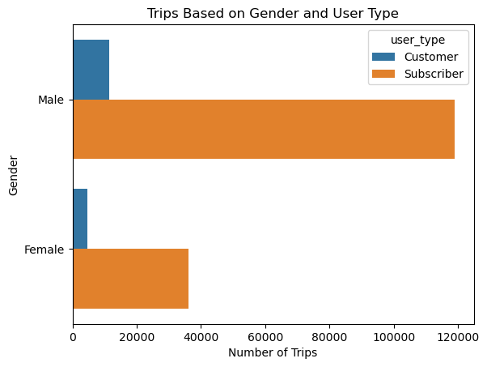

## the diffrence between Male and Female in duration and distance in trips.

During my investigation of the dataset,I found that female riders take an average of 12.48 minutes to complete 1.7 kilometers, while male riders take 10.7 minutes to complete 1.6 kilometers.

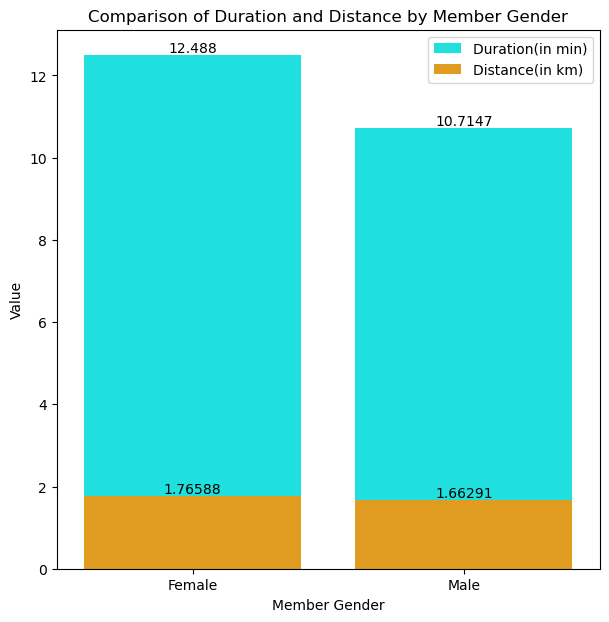